# Adult WEBL provisioning behavior in heat

# Check for zero-inflation

Observed zeros: 45 Predicted zeros: 9 Ratio: 0.20 G3;Model is underfitting zeros (probable zero-inflation). g

[output not shown]

G2;There were 12 warnings (use warnings() to see them) g

[output not shown]

# Overdispersion test

```
   dispersion ratio =    6.345
```

Pearson’s Chi-Squared = 1389.624 p-value = < 0.001 G3;Overdispersion detected. g

[output not shown]

# Check for zero-inflation

Observed zeros: 51 Predicted zeros: 11 Ratio: 0.22 G3;Model is underfitting zeros (probable zero-inflation). g

[output not shown]

G2;There were 50 or more warnings (use warnings() to see the first 50) g

[output not shown]

# Overdispersion test

dispersion ratio = 0.467 p-value = 0.288 G3;No overdispersion detected. g

[output not shown]

# Check for zero-inflation

Observed zeros: 45 Predicted zeros: 28 Ratio: 0.62 G3;Model is underfitting zeros (probable zero-inflation) (p = 0.056). g

[output not shown]

# Overdispersion test

dispersion ratio = 0.157 p-value = 0.088 G3;No overdispersion detected. g

[output not shown]

# Check for zero-inflation

Observed zeros: 51 Predicted zeros: 33 Ratio: 0.64 G3;Model is underfitting zeros (probable zero-inflation) (p = 0.040). g

[output not shown]

```
# Overdispersion test

 dispersion ratio = 0.879
          p-value = 0.688
```

```
G3;No overdispersion detected.
g
```

```r
check_zeroinflation(m)
```

```
# Check for zero-inflation

   Observed zeros: 45
  Predicted zeros: 47
            Ratio: 1.05
```

```
G3;Model seems ok, ratio of observed and predicted zeros is within the tolerance range (p = 0.704).
g
```

```r
m <- glmmTMB(valid_detections ~ poly(mean_temp_scaled,2) + poly(tod_h_scaled,2) + mean_nestling_age_scaled + site + (1|site:attempt_id) + year_fct,
           family = nbinom2(),
           ziformula = ~ 1,
           data = dplyr::filter(p,!is.na(mean_temp),
                                  # !is.na(julian_date),
                                  !is.na(mean_nestling_age),
                                  !is.na(tod_h),
                                  !is.na(site),
                                  !is.na(attempt_id),
                                  !is.na(year),
                                  species == "TRES"# ,
                                                # tod >= hms::as.hms('11:00:00', tz = "America/Los_Angeles"),
                                                # tod_end <= hms::as.hms('17:00:00',tz = "America/Los_Angeles"),
                                                # tod_end >= hms::as.hms('11:00:00', tz = "America/Los_Angeles")
                                                ) %>%
                        mutate(across(c(tod_h,mean_temp,julian_date,mean_nestling_age),
                                                    ~ scale(.x)[,1],
                                                    .names = "{.col}_scaled")),
           )

check_overdispersion(m)
```

```
# Overdispersion test

 dispersion ratio = 0.527
          p-value = 0.544
```

```
G3;No overdispersion detected.
g
```

```r
check_zeroinflation(m)
```

```
# Check for zero-inflation

   Observed zeros: 51
  Predicted zeros: 48
            Ratio: 0.95
```

```
G3;Model seems ok, ratio of observed and predicted zeros is within the tolerance range (p = 0.736).
g
```

Conclusion: use glmmTMB, negative binomial, with zero-inflation factor attempt_id (assuming that some pairs are just more likely to not feed than other pairs)

# Question 1: How do adult birds with active nests change their provisioning behavior during hot periods?

## Hypothesis 1: We hypothesized that adults will reduce their provisioning rates during hot periods because they must put more time and/or energy into thermoregulation to avoid hyperthermia

Prediction: negative correlation between temp and provisioning

### WEBL

```r
m_WEBL <- glmmTMB(valid_detections ~ poly(mean_temp_scaled,2) * habitat + poly(tod_h_scaled,2) + mean_nestling_age_scaled + brood_size_scaled + year_fct + (1|site:attempt_id),
           family = nbinom2(),
           ziformula = ~ (1|attempt_id),
           data = dplyr::filter(p,!is.na(mean_temp),
                                  # !is.na(julian_date),
                                  !is.na(mean_nestling_age),
                                  !is.na(brood_size),
                                  !is.na(tod_h),
                                  !is.na(site),
                                  !is.na(attempt_id),
                                  !is.na(year),
                                  species == "WEBL"# ,
                                                # tod >= hms::as.hms('11:00:00', tz = "America/Los_Angeles"),
                                                # tod_end <= hms::as.hms('17:00:00',tz = "America/Los_Angeles"),
                                                # tod_end >= hms::as.hms('11:00:00', tz = "America/Los_Angeles")
                                                ) %>%
                        mutate(across(c(tod_h,mean_temp,julian_date,mean_nestling_age,brood_size),
                                                    ~ scale(.x)[,1],
                                                    .names = "{.col}_scaled")),
           )

m_WEBL_linint <- glmmTMB(valid_detections ~ mean_temp_scaled * habitat + poly(mean_temp_scaled,degree = 2) + poly(tod_h_scaled,2) + mean_nestling_age_scaled + brood_size_scaled + year_fct + (1|site:attempt_id),
           family = nbinom2(),
           ziformula = ~ (1|attempt_id),
           data = dplyr::filter(p,!is.na(mean_temp),
                                  # !is.na(julian_date),
                                  !is.na(mean_nestling_age),
                                  !is.na(brood_size),
                                  !is.na(tod_h),
                                  !is.na(site),
                                  !is.na(attempt_id),
                                  !is.na(year),
                                  species == "WEBL"# ,
                                                # tod >= hms::as.hms('11:00:00', tz = "America/Los_Angeles"),
                                                # tod_end <= hms::as.hms('17:00:00',tz = "America/Los_Angeles"),
                                                # tod_end >= hms::as.hms('11:00:00', tz = "America/Los_Angeles")
                                                ) %>%
                        mutate(across(c(tod_h,mean_temp,julian_date,mean_nestling_age,brood_size),
                                                    ~ scale(.x)[,1],
                                                    .names = "{.col}_scaled")),
           )
```

```
G3;dropping columns from rank-deficient conditional model: poly(mean_temp_scaled, degree = 2)1
g
```

```r
m_WEBL_noint <- glmmTMB(valid_detections ~ habitat + poly(mean_temp_scaled,degree = 2) + poly(tod_h_scaled,2) + mean_nestling_age_scaled + brood_size_scaled + year_fct + (1|site:attempt_id),
           family = nbinom2(),
           ziformula = ~ (1|attempt_id),
           data = dplyr::filter(p,!is.na(mean_temp),
                                  # !is.na(julian_date),
                                  !is.na(mean_nestling_age),
                                  !is.na(brood_size),
                                  !is.na(tod_h),
                                  !is.na(site),
                                  !is.na(attempt_id),
                                  !is.na(year),
                                  species == "WEBL"# ,
                                                # tod >= hms::as.hms('11:00:00', tz = "America/Los_Angeles"),
                                                # tod_end <= hms::as.hms('17:00:00',tz = "America/Los_Angeles"),
                                                # tod_end >= hms::as.hms('11:00:00', tz = "America/Los_Angeles")
                                                ) %>%
                        mutate(across(c(tod_h,mean_temp,julian_date,mean_nestling_age,brood_size),
                                                    ~ scale(.x)[,1],
                                                    .names = "{.col}_scaled")),
           )




c <- anova(m_WEBL,m_WEBL_linint,m_WEBL_noint) %>% tibble() %>% mutate(Model = c("No temp * LC interaction","Linear temp * LC interaction","Squared temp * LC interaction"),.before = Df)

(tab <- c %>%
  as.tibble() %>%
  mutate(across(where(is.numeric),~round(.x,digits = 4)),
         P = `Pr(>Chisq)`) %>%
  dplyr::select(Model,AIC,Chisq,P) %>%
  mutate(across(c(AIC,Chisq), ~ round(.x, digits = 2)),
         P = if_else(P < 0.001,"<0.001",as.character(P))) %>% gt())
```

| Model | AIC | Chisq | P |
| --- | --- | --- | --- |
| No temp * LC interaction | 1841.26 | NA | NA |
| Linear temp * LC interaction | 1828.37 | 18.89 | <0.001 |
| Squared temp * LC interaction | 1831.25 | 3.12 | 0.3738 |

```r
gtsave(tab,"../figures/int_tab_provis_ch3_webl.html")

summary(m_WEBL_linint)
```

```
 Family: nbinom2  ( log )
Formula:          valid_detections ~ mean_temp_scaled * habitat + poly(mean_temp_scaled,
    degree = 2) + poly(tod_h_scaled, 2) + mean_nestling_age_scaled +
    brood_size_scaled + year_fct + (1 | site:attempt_id)
Zero inflation:                    ~(1 | attempt_id)
Data: dplyr::filter(p, !is.na(mean_temp), !is.na(mean_nestling_age),
    !is.na(brood_size), !is.na(tod_h), !is.na(site), !is.na(attempt_id),
    !is.na(year), species == "WEBL") %>% mutate(across(c(tod_h,
    mean_temp, julian_date, mean_nestling_age, brood_size), ~scale(.x)[,      1], .names = "{.col}_scaled"))

     AIC      BIC   logLik deviance df.resid
  1828.4   1899.8   -895.2   1790.4      298

Random effects:

Conditional model:
 Groups          Name        Variance Std.Dev.
 site:attempt_id (Intercept) 0.01914  0.1384
Number of obs: 317, groups:  site:attempt_id, 29

Zero-inflation model:
 Groups     Name        Variance Std.Dev.
 attempt_id (Intercept) 8.284    2.878
Number of obs: 317, groups:  attempt_id, 29

Dispersion parameter for nbinom2 family (): 4.65

Conditional model:
                                    Estimate Std. Error z value Pr(>|z|)
(Intercept)                          1.52573    0.28952   5.270 1.37e-07 ***
mean_temp_scaled                    -0.24709    0.12368  -1.998  0.04573 *
habitatOrchard                       1.04862    0.19558   5.361 8.25e-08 ***
habitatGrassland                     0.34828    0.21832   1.595  0.11066
habitatRow crop                      0.95976    0.18231   5.264 1.41e-07 ***
poly(mean_temp_scaled, degree = 2)1       NA         NA      NA       NA
poly(mean_temp_scaled, degree = 2)2 -0.35702    0.78544  -0.455  0.64943
poly(tod_h_scaled, 2)1              -0.55185    0.68309  -0.808  0.41917
poly(tod_h_scaled, 2)2               1.47226    1.00509   1.465  0.14297
mean_nestling_age_scaled             0.21680    0.04415   4.911 9.06e-07 ***
brood_size_scaled                    0.02533    0.06312   0.401  0.68825
year_fct2022                        -0.14558    0.24356  -0.598  0.55002
year_fct2023                        -0.31350    0.22561  -1.390  0.16467
mean_temp_scaled:habitatOrchard      0.42942    0.14915   2.879  0.00399 **
mean_temp_scaled:habitatGrassland   -0.12545    0.17889  -0.701  0.48312
mean_temp_scaled:habitatRow crop     0.16806    0.14925   1.126  0.26014
---
Signif. codes:  0 ‘***’ 0.001 ‘**’ 0.01 ‘*’ 0.05 ‘.’ 0.1 ‘ ’ 1

Zero-inflation model:
            Estimate Std. Error z value Pr(>|z|)
(Intercept)   -3.991      2.101  -1.899   0.0575 .
---
Signif. codes:  0 ‘***’ 0.001 ‘**’ 0.01 ‘*’ 0.05 ‘.’ 0.1 ‘ ’ 1
```

```r
summary(m_WEBL_noint)
```

```
 Family: nbinom2  ( log )
Formula:          valid_detections ~ habitat + poly(mean_temp_scaled, degree = 2) +
    poly(tod_h_scaled, 2) + mean_nestling_age_scaled + brood_size_scaled +      year_fct + (1 | site:attempt_id)
Zero inflation:                    ~(1 | attempt_id)
Data: dplyr::filter(p, !is.na(mean_temp), !is.na(mean_nestling_age),
    !is.na(brood_size), !is.na(tod_h), !is.na(site), !is.na(attempt_id),
    !is.na(year), species == "WEBL") %>% mutate(across(c(tod_h,
    mean_temp, julian_date, mean_nestling_age, brood_size), ~scale(.x)[,      1], .names = "{.col}_scaled"))

     AIC      BIC   logLik deviance df.resid
  1841.3   1901.4   -904.6   1809.3      301

Random effects:

Conditional model:
 Groups          Name        Variance Std.Dev.
 site:attempt_id (Intercept) 0.01634  0.1278
Number of obs: 317, groups:  site:attempt_id, 29

Zero-inflation model:
 Groups     Name        Variance Std.Dev.
 attempt_id (Intercept) 5.334    2.31
Number of obs: 317, groups:  attempt_id, 29

Dispersion parameter for nbinom2 family (): 4.35

Conditional model:
                                    Estimate Std. Error z value Pr(>|z|)
(Intercept)                          1.61787    0.28010   5.776 7.65e-09 ***
habitatOrchard                       0.96170    0.18465   5.208 1.91e-07 ***
habitatGrassland                     0.28185    0.21549   1.308    0.191
habitatRow crop                      0.82098    0.16735   4.906 9.30e-07 ***
poly(mean_temp_scaled, degree = 2)1 -1.58844    1.14856  -1.383    0.167
poly(mean_temp_scaled, degree = 2)2 -0.24816    0.74309  -0.334    0.738
poly(tod_h_scaled, 2)1               0.11277    0.67659   0.167    0.868
poly(tod_h_scaled, 2)2               0.62382    0.99350   0.628    0.530
mean_nestling_age_scaled             0.22355    0.04309   5.188 2.12e-07 ***
brood_size_scaled                    0.01191    0.06261   0.190    0.849
year_fct2022                        -0.11931    0.23967  -0.498    0.619
year_fct2023                        -0.23626    0.22084  -1.070    0.285
---
Signif. codes:  0 ‘***’ 0.001 ‘**’ 0.01 ‘*’ 0.05 ‘.’ 0.1 ‘ ’ 1

Zero-inflation model:
            Estimate Std. Error z value Pr(>|z|)
(Intercept)  -3.2152     0.7765  -4.141 3.46e-05 ***
---
Signif. codes:  0 ‘***’ 0.001 ‘**’ 0.01 ‘*’ 0.05 ‘.’ 0.1 ‘ ’ 1
```

```r
m_webl_q1h1 <- m_WEBL_linint

check_zeroinflation(m_WEBL_linint)
```

```
# Check for zero-inflation

   Observed zeros: 45
  Predicted zeros: 44
            Ratio: 0.98
```

```
G3;Model seems ok, ratio of observed and predicted zeros is within the tolerance range (p = 0.904).
g
```

```r
(t <- emtrends(m_webl_q1h1,specs = ~ habitat, var = c("mean_temp_scaled"),max.degree = 1) %>% test() %>%
   mutate(across(where(is.numeric), ~ round(.x, digits = 3)),
          df = round(df),
          p.value = if_else(p.value == 0.000,"<0.001",as.character(p.value))) %>%
   rename(Habitat = "habitat", `Max temp trend` = "mean_temp_scaled.trend",Df = "df", `Z-ratio` = "z.ratio", P = "p.value") %>%
   #group_by(degree) %>%
   gt())
```

| Habitat | Max temp trend | SE | Df | Z-ratio | P |
| --- | --- | --- | --- | --- | --- |
| Forest | -0.252 | 0.127 | Inf | -1.980 | 0.048 |
| Orchard | 0.178 | 0.097 | Inf | 1.835 | 0.066 |
| Grassland | -0.377 | 0.131 | Inf | -2.874 | 0.004 |
| Row crop | -0.084 | 0.080 | Inf | -1.052 | 0.293 |

```r
gtsave(t,"../figures/weblprovistrend_ch3.html")


ss_year_webl_provis <- m_webl_q1h1$frame %>%
  group_by(habitat,year_fct) %>%
  summarize(count_ind = n(),count_attempt = n_distinct(attempt_id)) %>%
  rowwise() %>%
  mutate(count = tibble(count_ind,count_attempt)) %>%
  dplyr::select(-c(count_ind, count_attempt)) %>%
  pivot_wider(values_from = count,names_from = year_fct) %>%
  as.tibble() %>% rename(Habitat = 'habitat') %>%
  ungroup() %>%
  mutate(`2021` = replace_na(`2021`,list(count_ind = 0,count_attempt = 0))) %>%
  mutate(Total = `2021` + `2022` + `2023`) %>%
  rowwise() %>%
  mutate(`2021` = paste0(`2021`$count_ind,", ",`2021`$count_attempt),
         `2022` = paste0(`2022`$count_ind,", ",`2022`$count_attempt),
         `2023` = paste0(`2023`$count_ind,", ",`2023`$count_attempt),
         Total = paste0(Total$count_ind,", ",Total$count_attempt)
  )
(t_ss_year_webl_provis <- ss_year_webl_provis %>% gt() %>%
    grand_summary_rows(columns = -c(Habitat),fns = list(id = "Total") ~ {
      t <- str_split(.,", ",simplify = TRUE)
      t[,1] %>% as.numeric() %>% sum(na.rm = TRUE) %>% paste(t[,2] %>% as.numeric() %>% sum(na.rm = TRUE),sep = ", ")
    })
)
```

|  | Habitat | 2022 | 2023 | 2021 | Total |
| --- | --- | --- | --- | --- | --- |
|  | Forest | 40, 3 | 29, 3 | 0, 0 | 69, 6 |
|  | Orchard | 32, 4 | 56, 5 | 9, 2 | 97, 11 |
|  | Grassland | 16, 2 | 12, 2 | 12, 1 | 40, 5 |
|  | Row crop | 65, 3 | 46, 4 | 0, 0 | 111, 7 |
| Total | — | 153, 12 | 143, 14 | 21, 3 | 317, 29 |

```r
t_ss_year_webl_provis %>% gtsave("../figures/ss_year_webl_provis_ch3.html")

samp <- m_webl_q1h1$frame %>% group_by(habitat) %>% summarize(count = n())
samp %>% gt() %>% gtsave("../figures/ss_webl_provis_ch3.html")


dat_text_webl_q1h1 <- data.frame(
  label = paste("N =",samp$count),
  group   = factor(c("Forest","Orchard","Grassland","Row crop"))
)

## num nestboxes
m_webl_q1h1$frame %>% pull(attempt_id) %>% unique() %>% length()
```

```
[1] 29
```

```r
data_webl_q1h1 = dplyr::filter(p,!is.na(mean_temp),
                                  # !is.na(julian_date),
                                  !is.na(mean_nestling_age),
                                  !is.na(brood_size),
                                  !is.na(tod_h),
                                  !is.na(site),
                                  !is.na(attempt_id),
                                  !is.na(year),
                                  species == "WEBL"# ,
                                                # tod >= hms::as.hms('11:00:00', tz = "America/Los_Angeles"),
                                                # tod_end <= hms::as.hms('17:00:00',tz = "America/Los_Angeles"),
                                                # tod_end >= hms::as.hms('11:00:00', tz = "America/Los_Angeles")
                                                ) %>%
                        mutate(across(c(tod_h,mean_temp,julian_date,mean_nestling_age,brood_size),
                                                    ~ scale(.x)[,1],
                                                    .names = "{.col}_scaled"))


mean_temp_webl_q1h1 <- mean(data_webl_q1h1 %>% pull(mean_temp))
sd_temp_webl_q1h1 <- sd(data_webl_q1h1 %>% pull(mean_temp))


temp_trans_webl_q1h1 <- trans_new("temp_trans_webl_q1h1",
                             transform = function(x){(x * sd_temp_webl_q1h1) + mean_temp_webl_q1h1},
                             inverse = function(x){x})

(fig5_webl <- predict_response(m_webl_q1h1,terms = c("mean_temp_scaled [all]","habitat")) %>%
    plot(line_size = 1.5,alpha = .2,show_data = TRUE,limit_range = TRUE) +
    aes(linetype = .data[["group"]]) +
    theme_classic() +
    facet_wrap(~ group, ncol = 2) +
    xlab("Mean temperature (\u00b0C)") +
    ylab("Provisioning (count/hour)") +
    scale_fill_viridis(discrete = TRUE) +
    scale_color_viridis(discrete = TRUE) +
    theme(text = element_text(size = 16)) +
    labs(title =  "WEBL provis: max * LC interaction") +
    scale_x_continuous(trans = temp_trans_webl_q1h1,
                       breaks = c((20-mean_temp_webl_q1h1)/sd_temp_webl_q1h1,
                                  (25-mean_temp_webl_q1h1)/sd_temp_webl_q1h1,
                                  (30-mean_temp_webl_q1h1)/sd_temp_webl_q1h1,
                                  (35-mean_temp_webl_q1h1)/sd_temp_webl_q1h1,
                                  (40-mean_temp_webl_q1h1)/sd_temp_webl_q1h1),
                       # breaks = c(20,30,40,50),
                       # labels = c("20","30","40","50"),
                       # limits = c((15-mean(g$meanmaxtempI,na.rm = TRUE))/sd(g$meanmaxtempI,na.rm = TRUE),
                       #            (55-mean(g$meanmaxtempI,na.rm = TRUE))/sd(g$meanmaxtempI,na.rm = TRUE))
                       # limits = c(18,5)
    ) +
    scale_linetype_manual(values = c("Forest" = "solid","Orchard" = "dashed","Grassland" = "solid","Row crop" = "dotted")) +
    #ylim(-5,5) +
    geom_text(data = dat_text_webl_q1h1, mapping = aes(x = -Inf, y = Inf,label = label),hjust = -.2, vjust = 1.2,inherit.aes = FALSE) +
    theme(legend.position = "none")
)
```

```
G3;Data points may overlap. Use the `jitter` argument to add some amount of random variation to the
  location of data points and avoid overplotting.
gScale for colour is already present.
```

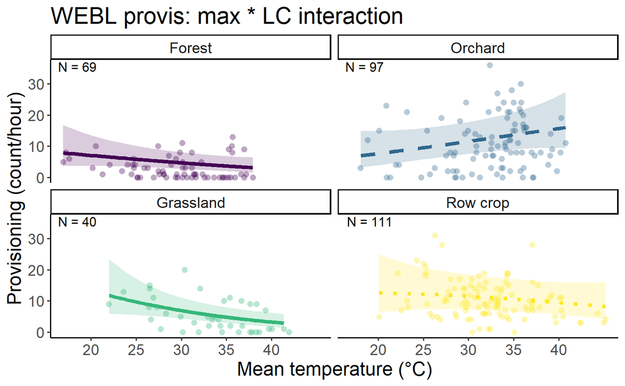

```r
ggsave("../figures/provisbymaxtempxhab_WEBL_q1h1.png",plot =  fig5_webl, width = 10, height = 6.6)
```

Another question out of this is, are the adults responding to their own physiological state or are they responding to nestlings’ condition? The tough part is that I could imagine that they’re responding to nestlings’ begging behavior. Does begging behavior peak at some intermediate condition (i.e. when nestlings are really hungry but not yet weakened by it), or is it strongest when nestlings are fed well?

From the reading, it looks like what we should expect is that in resource-poor environments (i.e. agriculture), provisioning should respond to quality of nestlings, whereas in resource-poor environments, provisioning should respond to need of nestlings. But also, in the short term, nestling begging rate is driven by hunger, and generally reduced in small nestlings in large broods.

### TRES

```
G3;Data points may overlap. Use the `jitter` argument to add some amount of random variation to the
  location of data points and avoid overplotting.
gScale for colour is already present.
```

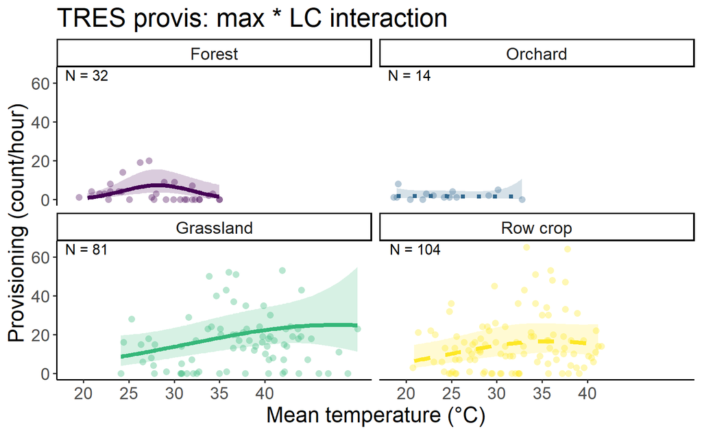

```r
(fig1_tres <- predict_response(m_tres_q1h1,terms = c("mean_temp_scaled [all]","habitat")) %>%
    plot(line_size = 1.5,alpha = .2,show_data = TRUE,limit_range = TRUE) +
    aes(linetype = .data[["group"]]) +
    theme_classic() +
    facet_wrap(~ group, ncol = 2) +
    xlab("Mean temperature (\u00b0C)") +
    ylab("Provisioning (count/hour)") +
    scale_fill_viridis(discrete = TRUE) +
    scale_color_viridis(discrete = TRUE) +
    theme(text = element_text(size = 16)) +
    labs(title =  "TRES provis: max * LC interaction") +
    scale_x_continuous(trans = temp_trans_tres_q1h1,
                       breaks = c((20-mean_temp_tres_q1h1)/sd_temp_tres_q1h1,
                                  (25-mean_temp_tres_q1h1)/sd_temp_tres_q1h1,
                                  (30-mean_temp_tres_q1h1)/sd_temp_tres_q1h1,
                                  (35-mean_temp_tres_q1h1)/sd_temp_tres_q1h1,
                                  (40-mean_temp_tres_q1h1)/sd_temp_tres_q1h1),
                       # breaks = c(20,30,40,50),
                       # labels = c("20","30","40","50"),
                       # limits = c((15-mean(g$meanmaxtempI,na.rm = TRUE))/sd(g$meanmaxtempI,na.rm = TRUE),
                       #            (55-mean(g$meanmaxtempI,na.rm = TRUE))/sd(g$meanmaxtempI,na.rm = TRUE))
                       # limits = c(18,5)
    ) +
    scale_linetype_manual(values = c("Forest" = "solid","Orchard" = "dotted","Grassland" = "solid","Row crop" = "dashed")) +
    #ylim(-5,5) +
    geom_text(data = dat_text_tres_q1h1, mapping = aes(x = -Inf, y = Inf,label = label),hjust = -.2, vjust = 1.2,inherit.aes = FALSE) +
    theme(legend.position = "none")
)
```

## Q1H2

How do adult birds with active nests change their provisioning behavior during hot periods? We hypothesized that adult birds will

2. (H2) maintain total provisioning visits by increasing visit rates during cooler hours of the day. Because of the spottiness of the data, I don’t think I’ll be able to compare whole days to other whole days. Instead, I think what we should expect is that morning - afternoon average hourly visits will be greater when max daily temp is greater.

```r
p_sum <- p %>%
  mutate(temp_code = if_else(mean_temp < 30, "c","h")) %>%
  group_by(site,attempt,habitat,species,attempt_id,nestbox,julian_date,date,year,year_fct,temp_code,mean_nestling_age,mean_nestling_condition,female_condition,brood_size,cort_s1_mother,cort_s2_mother) %>%
  summarize(max_temp = max(mean_temp,na.rm = TRUE),
            mean_temp = mean(mean_temp, na.rm = TRUE),
            min_temp = min(mean_temp,na.rm = TRUE),
            mean_visits = mean(valid_detections,na.rm = TRUE),
            n = n(),
            .groups = "keep") %>%
  ungroup() %>%
  pivot_wider(names_from = temp_code,values_from = c(max_temp, mean_temp, min_temp, mean_visits,n)) %>%
  mutate(diff_visits = mean_visits_c - mean_visits_h,
         diff_temp = mean_temp_h - mean_temp_c) %>%
  dplyr::filter(!is.na(diff_visits))
```

[output not shown]

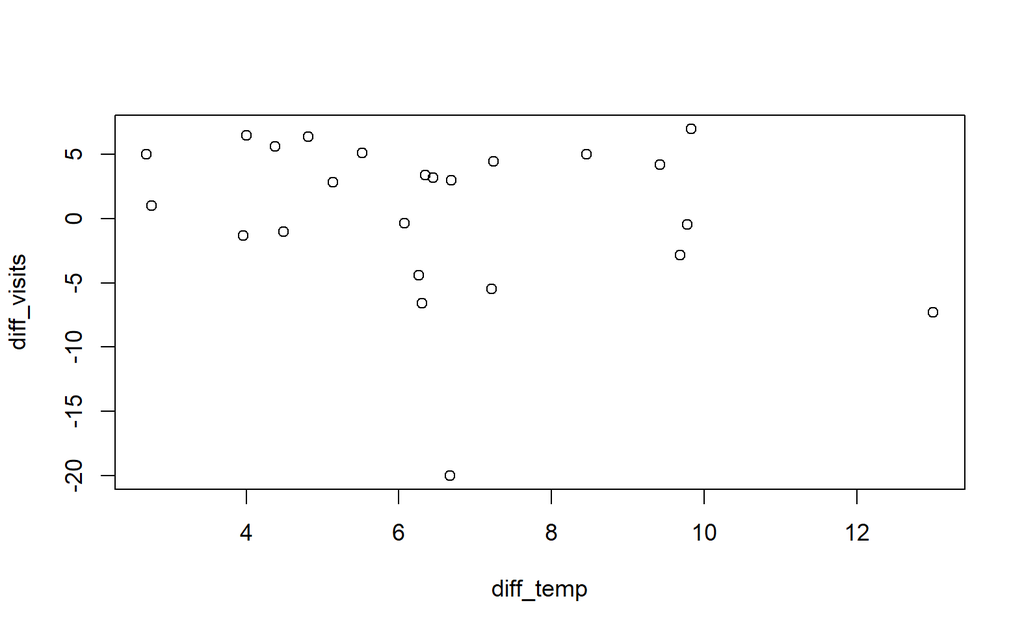

```r
plot(diff_visits ~ diff_temp, data = dplyr::filter(p_sum,species == "WEBL"))
```

Now that I have the dataset, I can model it. Will use similar covariates to provisioning model. Wonder if I’ll need to use a zero inflated model this time? Because it’s a mean of counts, might be able to use a Gaussian model.

```
[1]  14 102
```

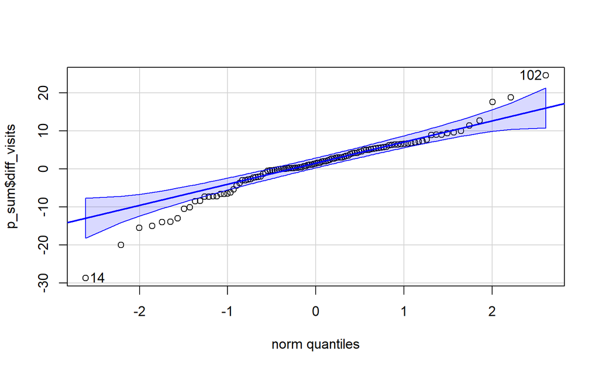

```r
library(car)
qqPlot(p_sum$diff_visits)
```

```
G2;H2;Warningh in sqrt(p_sum$diff_visits) : NaNs producedg
```

```
[1] 102 101
```

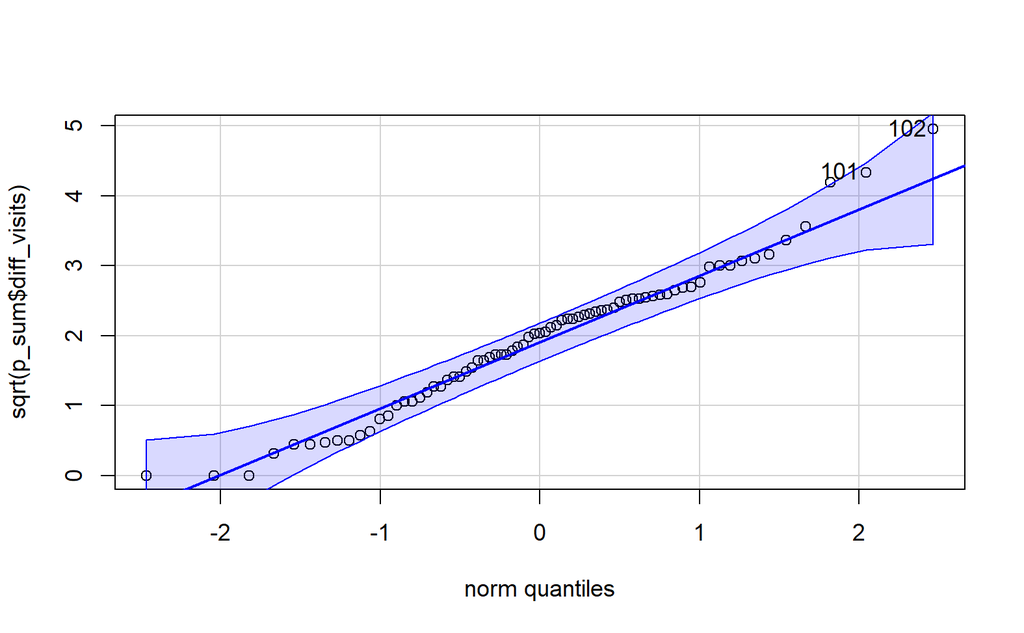

```r
qqPlot(sqrt(p_sum$diff_visits))
```

Square root transformation seems to ensure normality in diff_visits, so I’ll use a Gaussian model

```r
m_WEBL <- lmer(sqrt(diff_visits) ~ diff_temp_scaled + mean_nestling_age_scaled + brood_size_scaled + year_fct + (1|site:attempt_id),
               data = dplyr::filter(p_sum,
                                    !is.na(diff_visits),
                                    !is.na(diff_temp),
                                    !is.na(mean_nestling_age),
                                    !is.na(brood_size),
                                    !is.na(year_fct),
                                    !is.na(site),
                                    !is.na(attempt_id),
                                    species == "WEBL") %>%
                 mutate(across(c(diff_temp,mean_nestling_age,brood_size),
                               ~ scale(.x)[,1],
                                                    .names = "{.col}_scaled"))
                                                    )
```

[output not shown]

```r
summary(m_WEBL)
```

```
Linear mixed model fit by REML. t-tests use Satterthwaite's method ['lmerModLmerTest']
Formula: sqrt(diff_visits) ~ diff_temp_scaled + mean_nestling_age_scaled +
    brood_size_scaled + year_fct + (1 | site:attempt_id)
   Data: dplyr::filter(p_sum, !is.na(diff_visits), !is.na(diff_temp),
    !is.na(mean_nestling_age), !is.na(brood_size), !is.na(year_fct),
    !is.na(site), !is.na(attempt_id), species == "WEBL") %>%
    mutate(across(c(diff_temp, mean_nestling_age, brood_size),
        ~scale(.x)[, 1], .names = "{.col}_scaled"))

REML criterion at convergence: 13.7

Scaled residuals:
    Min      1Q  Median      3Q     Max
-0.6956 -0.4674  0.1310  0.3599  0.8806

Random effects:
 Groups          Name        Variance Std.Dev.
 site:attempt_id (Intercept) 0.08566  0.2927
 Residual                    0.03214  0.1793
Number of obs: 14, groups:  site:attempt_id, 11

Fixed effects:
                         Estimate Std. Error       df t value Pr(>|t|)
(Intercept)               2.82169    0.32167  6.84490   8.772 5.75e-05 ***
diff_temp_scaled         -0.01737    0.12144  7.92086  -0.143  0.88986
mean_nestling_age_scaled  0.32363    0.08116  5.33960   3.987  0.00915 **
brood_size_scaled         0.11202    0.13374  5.90171   0.838  0.43485
year_fct2022             -1.00240    0.37578  7.11843  -2.667  0.03162 *
year_fct2023             -0.82489    0.45017  6.62268  -1.832  0.11197
---
Signif. codes:  0 ‘***’ 0.001 ‘**’ 0.01 ‘*’ 0.05 ‘.’ 0.1 ‘ ’ 1

Correlation of Fixed Effects:
            (Intr) dff_t_ mn_n__ brd_s_ y_2022
dff_tmp_scl -0.313
mn_nstlng__  0.114  0.194
brd_sz_scld  0.524  0.084  0.041
yer_fct2022 -0.928  0.350 -0.121 -0.515
yer_fct2023 -0.873  0.379 -0.017 -0.571  0.825
```

```r
m_WEBL <- lmer(sqrt(diff_visits) ~ max_temp_h_scaled + mean_nestling_age_scaled + brood_size_scaled + year_fct + (1|site:attempt_id),
               data = dplyr::filter(p_sum,
                                    !is.na(diff_visits),
                                    !is.na(max_temp_h),
                                    !is.na(mean_nestling_age),
                                    !is.na(brood_size),
                                    !is.na(year_fct),
                                    !is.na(site),
                                    !is.na(attempt_id),
                                    species == "WEBL") %>%
                 mutate(across(c(max_temp_h,mean_nestling_age,brood_size),
                               ~ scale(.x)[,1],
                                                    .names = "{.col}_scaled"))
                                                    )
```

[output not shown]

```r
summary(m_WEBL)
```

```
Linear mixed model fit by REML. t-tests use Satterthwaite's method ['lmerModLmerTest']
Formula: sqrt(diff_visits) ~ max_temp_h_scaled + mean_nestling_age_scaled +
    brood_size_scaled + year_fct + (1 | site:attempt_id)
   Data: dplyr::filter(p_sum, !is.na(diff_visits), !is.na(max_temp_h),
    !is.na(mean_nestling_age), !is.na(brood_size), !is.na(year_fct),
    !is.na(site), !is.na(attempt_id), species == "WEBL") %>%
    mutate(across(c(max_temp_h, mean_nestling_age, brood_size),
        ~scale(.x)[, 1], .names = "{.col}_scaled"))

REML criterion at convergence: 13.9

Scaled residuals:
    Min      1Q  Median      3Q     Max
-0.7599 -0.4518  0.1357  0.3506  0.9297

Random effects:
 Groups          Name        Variance Std.Dev.
 site:attempt_id (Intercept) 0.08383  0.2895
 Residual                    0.03159  0.1777
Number of obs: 14, groups:  site:attempt_id, 11

Fixed effects:
                         Estimate Std. Error       df t value Pr(>|t|)
(Intercept)               2.80628    0.30237  6.30201   9.281 6.63e-05 ***
max_temp_h_scaled        -0.04247    0.10008  7.65619  -0.424   0.6830
mean_nestling_age_scaled  0.32465    0.07894  4.40503   4.113   0.0120 *
brood_size_scaled         0.09714    0.13753  6.11380   0.706   0.5060
year_fct2022             -0.97639    0.34893  6.39546  -2.798   0.0292 *
year_fct2023             -0.80145    0.41240  6.10713  -1.943   0.0991 .
---
Signif. codes:  0 ‘***’ 0.001 ‘**’ 0.01 ‘*’ 0.05 ‘.’ 0.1 ‘ ’ 1

Correlation of Fixed Effects:
            (Intr) mx_t__ mn_n__ brd_s_ y_2022
mx_tmp_h_sc  0.008
mn_nstlng__  0.188  0.038
brd_sz_scld  0.561  0.283  0.035
yer_fct2022 -0.919 -0.049 -0.207 -0.572
yer_fct2023 -0.858  0.005 -0.100 -0.626  0.797
```

```r
m_WEBL <- lmer(sqrt(mean_visits_h) ~ max_temp_h_scaled + mean_nestling_age_scaled + brood_size_scaled + year_fct + (1|site:attempt_id),
               data = dplyr::filter(p_sum,
                                    !is.na(mean_visits_h),
                                    !is.na(max_temp_h),
                                    !is.na(mean_nestling_age),
                                    !is.na(brood_size),
                                    !is.na(year_fct),
                                    !is.na(site),
                                    !is.na(attempt_id),
                                    species == "WEBL") %>%
                 mutate(across(c(max_temp_h,mean_nestling_age,brood_size),
                               ~ scale(.x)[,1],
                                                    .names = "{.col}_scaled"))
                                                    )

summary(m_WEBL)
```

```
Linear mixed model fit by REML. t-tests use Satterthwaite's method ['lmerModLmerTest']
Formula: sqrt(mean_visits_h) ~ max_temp_h_scaled + mean_nestling_age_scaled +
    brood_size_scaled + year_fct + (1 | site:attempt_id)
   Data: dplyr::filter(p_sum, !is.na(mean_visits_h), !is.na(max_temp_h),
    !is.na(mean_nestling_age), !is.na(brood_size), !is.na(year_fct),
    !is.na(site), !is.na(attempt_id), species == "WEBL") %>%
    mutate(across(c(max_temp_h, mean_nestling_age, brood_size),
        ~scale(.x)[, 1], .names = "{.col}_scaled"))

REML criterion at convergence: 72.2

Scaled residuals:
     Min       1Q   Median       3Q      Max
-0.85739 -0.45756 -0.06984  0.26264  1.27522

Random effects:
 Groups          Name        Variance Std.Dev.
 site:attempt_id (Intercept) 1.3867   1.1776
 Residual                    0.4876   0.6982
Number of obs: 24, groups:  site:attempt_id, 18

Fixed effects:
                         Estimate Std. Error      df t value Pr(>|t|)
(Intercept)                2.9587     1.0847 13.1714   2.728   0.0171 *
max_temp_h_scaled         -0.0796     0.2472  9.7219  -0.322   0.7543
mean_nestling_age_scaled   0.3597     0.2421  7.3140   1.485   0.1792
brood_size_scaled          0.3936     0.3393 12.3488   1.160   0.2680
year_fct2022              -0.7154     1.2247 13.3979  -0.584   0.5688
year_fct2023              -0.6077     1.1623 12.4871  -0.523   0.6103
---
Signif. codes:  0 ‘***’ 0.001 ‘**’ 0.01 ‘*’ 0.05 ‘.’ 0.1 ‘ ’ 1

Correlation of Fixed Effects:
            (Intr) mx_t__ mn_n__ brd_s_ y_2022
mx_tmp_h_sc -0.145
mn_nstlng__  0.157 -0.378
brd_sz_scld  0.394  0.065 -0.084
yer_fct2022 -0.920  0.142 -0.194 -0.409
yer_fct2023 -0.911  0.111 -0.096 -0.339  0.834
```

```r
m_WEBL <- lmer(sqrt(mean_visits_h) ~ max_temp_h_scaled * habitat + mean_nestling_age_scaled + brood_size_scaled + year_fct + (1|site:attempt_id),
               data = dplyr::filter(p_sum,
                                    !is.na(mean_visits_h),
                                    !is.na(max_temp_h),
                                    !is.na(mean_nestling_age),
                                    !is.na(brood_size),
                                    !is.na(year_fct),
                                    !is.na(site),
                                    !is.na(attempt_id),
                                    species == "WEBL") %>%
                 mutate(across(c(max_temp_h,mean_nestling_age,brood_size),
                               ~ scale(.x)[,1],
                                                    .names = "{.col}_scaled"))
                                                    )

summary(m_WEBL)
```

```
Linear mixed model fit by REML. t-tests use Satterthwaite's method ['lmerModLmerTest']
Formula: sqrt(mean_visits_h) ~ max_temp_h_scaled * habitat + mean_nestling_age_scaled +
    brood_size_scaled + year_fct + (1 | site:attempt_id)
   Data: dplyr::filter(p_sum, !is.na(mean_visits_h), !is.na(max_temp_h),
    !is.na(mean_nestling_age), !is.na(brood_size), !is.na(year_fct),
    !is.na(site), !is.na(attempt_id), species == "WEBL") %>%
    mutate(across(c(max_temp_h, mean_nestling_age, brood_size),
        ~scale(.x)[, 1], .names = "{.col}_scaled"))

REML criterion at convergence: 55.8

Scaled residuals:
     Min       1Q   Median       3Q      Max
-1.32956 -0.29984  0.07202  0.30319  1.10524

Random effects:
 Groups          Name        Variance Std.Dev.
 site:attempt_id (Intercept) 0.8224   0.9069
 Residual                    0.6971   0.8349
Number of obs: 24, groups:  site:attempt_id, 18

Fixed effects:
                                    Estimate Std. Error        df t value Pr(>|t|)
(Intercept)                         0.839897   1.550377  8.186194   0.542   0.6024
max_temp_h_scaled                  -0.259055   0.447684  3.626291  -0.579   0.5968
habitatOrchard                      2.392503   0.998157  7.230730   2.397   0.0466 *
habitatGrassland                    0.960529   1.644362  7.789037   0.584   0.5757
habitatRow crop                     1.508981   0.880093  5.740743   1.715   0.1395
mean_nestling_age_scaled            0.388363   0.280754  5.620019   1.383   0.2190
brood_size_scaled                  -0.009769   0.395197  8.375219  -0.025   0.9809
year_fct2022                        0.459440   1.443420  9.210884   0.318   0.7574
year_fct2023                        0.090249   1.242130  8.098000   0.073   0.9438
max_temp_h_scaled:habitatOrchard   -0.021375   0.987983 11.762773  -0.022   0.9831
max_temp_h_scaled:habitatGrassland  0.029140   1.080185 11.523275   0.027   0.9789
max_temp_h_scaled:habitatRow crop   0.175961   0.663411  3.976356   0.265   0.8040
---
Signif. codes:  0 ‘***’ 0.001 ‘**’ 0.01 ‘*’ 0.05 ‘.’ 0.1 ‘ ’ 1

Correlation of Fixed Effects:
            (Intr) mx_t__ hbttOr hbttGr hbttRc mn_n__ brd_s_ y_2022 y_2023 m___:O m___:G
mx_tmp_h_sc -0.055
habttOrchrd -0.706 -0.062
hbttGrsslnd -0.570 -0.054  0.513
habittRwcrp -0.468 -0.090  0.548  0.384
mn_nstlng__  0.230 -0.349 -0.136  0.056 -0.199
brd_sz_scld  0.585 -0.150 -0.461 -0.493 -0.298 -0.018
yer_fct2022 -0.916  0.175  0.537  0.501  0.247 -0.239 -0.591
yer_fct2023 -0.860  0.134  0.426  0.329  0.152 -0.183 -0.440  0.867
mx_tmp_h_:O  0.279 -0.493 -0.368 -0.076 -0.004  0.216  0.188 -0.340 -0.349
mx_tmp_h_:G  0.227 -0.391 -0.166 -0.689 -0.058 -0.099  0.470 -0.324 -0.130  0.218
mx_tmp__:Rc  0.116 -0.684 -0.017 -0.026  0.190  0.190  0.261 -0.186 -0.169  0.356  0.325
```

Looks like no effect of hot parts of the day directly on shifting provisioning, or mediation by habitat, at least for WEBL

```r
library(car)
qqPlot(p_sum$diff_visits)
qqPlot(sqrt(p_sum$diff_visits))
```

[output not shown]

Square root transformation seems to ensure normality in diff_visits, so I’ll use a Gaussian model

```r
m_TRES <- lmer(sqrt(diff_visits) ~ diff_temp_scaled + mean_nestling_age_scaled + brood_size_scaled + year_fct + (1|site:attempt_id),
               data = dplyr::filter(p_sum,
                                    !is.na(diff_visits),
                                    !is.na(diff_temp),
                                    !is.na(mean_nestling_age),
                                    !is.na(brood_size),
                                    !is.na(year_fct),
                                    !is.na(site),
                                    !is.na(attempt_id),
                                    species == "TRES") %>%
                 mutate(across(c(diff_temp,mean_nestling_age,brood_size),
                               ~ scale(.x)[,1],
                                                    .names = "{.col}_scaled"))
                                                    )
```

[output not shown]

```r
summary(m_TRES)
```

```
Linear mixed model fit by REML. t-tests use Satterthwaite's method ['lmerModLmerTest']
Formula: sqrt(diff_visits) ~ diff_temp_scaled + mean_nestling_age_scaled +
    brood_size_scaled + year_fct + (1 | site:attempt_id)
   Data: dplyr::filter(p_sum, !is.na(diff_visits), !is.na(diff_temp),
    !is.na(mean_nestling_age), !is.na(brood_size), !is.na(year_fct),
    !is.na(site), !is.na(attempt_id), species == "TRES") %>%
    mutate(across(c(diff_temp, mean_nestling_age, brood_size),
        ~scale(.x)[, 1], .names = "{.col}_scaled"))

REML criterion at convergence: 20.1

Scaled residuals:
       Min         1Q     Median         3Q        Max
-0.0028762 -0.0014549 -0.0003215  0.0015545  0.0035193

Random effects:
 Groups          Name        Variance  Std.Dev.
 site:attempt_id (Intercept) 7.196e-01 0.848309
 Residual                    5.821e-06 0.002413
Number of obs: 11, groups:  site:attempt_id, 10

Fixed effects:
                          Estimate Std. Error        df t value Pr(>|t|)
(Intercept)               3.035267   0.680348  5.000000   4.461  0.00663 **
diff_temp_scaled         -0.424212   0.416630  5.000000  -1.018  0.35529
mean_nestling_age_scaled  0.942329   0.058923  5.000000  15.993 1.74e-05 ***
brood_size_scaled         0.003972   0.500379  5.000000   0.008  0.99397
year_fct2022             -0.730717   1.313665  5.000000  -0.556  0.60202
year_fct2023             -2.061935   0.842155  5.000000  -2.448  0.05805 .
---
Signif. codes:  0 ‘***’ 0.001 ‘**’ 0.01 ‘*’ 0.05 ‘.’ 0.1 ‘ ’ 1

Correlation of Fixed Effects:
            (Intr) dff_t_ mn_n__ brd_s_ y_2022
dff_tmp_scl -0.240
mn_nstlng__  0.240 -1.000
brd_sz_scld -0.683  0.172 -0.172
yer_fct2022 -0.858  0.321 -0.320  0.830
yer_fct2023 -0.730  0.582 -0.582  0.359  0.610
optimizer (nloptwrap) convergence code: 0 (OK)
unable to evaluate scaled gradient
Model failed to converge: degenerate  Hessian with 1 negative eigenvalues
```

```r
m_TRES <- lmer(sqrt(diff_visits) ~ max_temp_h_scaled + mean_nestling_age_scaled + brood_size_scaled + year_fct + (1|site:attempt_id),
               data = dplyr::filter(p_sum,
                                    !is.na(diff_visits),
                                    !is.na(max_temp_h),
                                    !is.na(mean_nestling_age),
                                    !is.na(brood_size),
                                    !is.na(year_fct),
                                    !is.na(site),
                                    !is.na(attempt_id),
                                    species == "TRES") %>%
                 mutate(across(c(max_temp_h,mean_nestling_age,brood_size),
                               ~ scale(.x)[,1],
                                                    .names = "{.col}_scaled"))
                                                    )
```

[output not shown]

```r
summary(m_TRES)
```

```
Linear mixed model fit by REML. t-tests use Satterthwaite's method ['lmerModLmerTest']
Formula: sqrt(diff_visits) ~ max_temp_h_scaled + mean_nestling_age_scaled +
    brood_size_scaled + year_fct + (1 | site:attempt_id)
   Data: dplyr::filter(p_sum, !is.na(diff_visits), !is.na(max_temp_h),
    !is.na(mean_nestling_age), !is.na(brood_size), !is.na(year_fct),
    !is.na(site), !is.na(attempt_id), species == "TRES") %>%
    mutate(across(c(max_temp_h, mean_nestling_age, brood_size),
        ~scale(.x)[, 1], .names = "{.col}_scaled"))

REML criterion at convergence: 20.1

Scaled residuals:
       Min         1Q     Median         3Q        Max
-0.0033457 -0.0013708 -0.0002974  0.0013802  0.0028857

Random effects:
 Groups          Name        Variance  Std.Dev.
 site:attempt_id (Intercept) 7.386e-01 0.859400
 Residual                    5.873e-06 0.002423
Number of obs: 11, groups:  site:attempt_id, 10

Fixed effects:
                         Estimate Std. Error       df t value Pr(>|t|)
(Intercept)               3.05307    0.69723  5.00000   4.379  0.00716 **
max_temp_h_scaled        -0.42147    0.44880  5.00000  -0.939  0.39079
mean_nestling_age_scaled  0.85432    0.02990  5.00000  28.573 9.84e-07 ***
brood_size_scaled        -0.08892    0.53506  5.00000  -0.166  0.87452
year_fct2022             -0.63473    1.30947  5.00000  -0.485  0.64836
year_fct2023             -2.10839    0.90487  5.00000  -2.330  0.06721 .
---
Signif. codes:  0 ‘***’ 0.001 ‘**’ 0.01 ‘*’ 0.05 ‘.’ 0.1 ‘ ’ 1

Correlation of Fixed Effects:
            (Intr) mx_t__ mn_n__ brd_s_ y_2022
mx_tmp_h_sc -0.281
mn_nstlng__ -0.281  0.998
brd_sz_scld -0.702  0.359  0.359
yer_fct2022 -0.861  0.271  0.270  0.844
yer_fct2023 -0.731  0.642  0.641  0.462  0.580
```

```r
m_TRES <- lmer(sqrt(mean_visits_h) ~ max_temp_h_scaled + mean_nestling_age_scaled + brood_size_scaled + year_fct + (1|site:attempt_id),
               data = dplyr::filter(p_sum,
                                    !is.na(mean_visits_h),
                                    !is.na(max_temp_h),
                                    !is.na(mean_nestling_age),
                                    !is.na(brood_size),
                                    !is.na(year_fct),
                                    !is.na(site),
                                    !is.na(attempt_id),
                                    species == "TRES") %>%
                 mutate(across(c(max_temp_h,mean_nestling_age,brood_size),
                               ~ scale(.x)[,1],
                                                    .names = "{.col}_scaled"))
                                                    )

summary(m_TRES)
```

```
Linear mixed model fit by REML. t-tests use Satterthwaite's method ['lmerModLmerTest']
Formula: sqrt(mean_visits_h) ~ max_temp_h_scaled + mean_nestling_age_scaled +
    brood_size_scaled + year_fct + (1 | site:attempt_id)
   Data: dplyr::filter(p_sum, !is.na(mean_visits_h), !is.na(max_temp_h),
    !is.na(mean_nestling_age), !is.na(brood_size), !is.na(year_fct),
    !is.na(site), !is.na(attempt_id), species == "TRES") %>%
    mutate(across(c(max_temp_h, mean_nestling_age, brood_size),
        ~scale(.x)[, 1], .names = "{.col}_scaled"))

REML criterion at convergence: 79.9

Scaled residuals:
    Min      1Q  Median      3Q     Max
-1.1707 -0.4432 -0.1019  0.4874  1.1754

Random effects:
 Groups          Name        Variance Std.Dev.
 site:attempt_id (Intercept) 2.381    1.543
 Residual                    1.875    1.369
Number of obs: 22, groups:  site:attempt_id, 16

Fixed effects:
                         Estimate Std. Error      df t value Pr(>|t|)
(Intercept)                2.2575     1.2454 12.6283   1.813  0.09371 .
max_temp_h_scaled          1.5357     0.4652  9.6059   3.301  0.00844 **
mean_nestling_age_scaled   0.2199     0.4141  9.2254   0.531  0.60804
brood_size_scaled          0.3372     0.7548 11.7092   0.447  0.66324
year_fct2022               0.4242     1.7577 12.9041   0.241  0.81309
year_fct2023               1.3063     1.4915 13.8799   0.876  0.39603
---
Signif. codes:  0 ‘***’ 0.001 ‘**’ 0.01 ‘*’ 0.05 ‘.’ 0.1 ‘ ’ 1

Correlation of Fixed Effects:
            (Intr) mx_t__ mn_n__ brd_s_ y_2022
mx_tmp_h_sc -0.261
mn_nstlng__ -0.079 -0.090
brd_sz_scld -0.573  0.154  0.158
yer_fct2022 -0.848  0.145  0.002  0.676
yer_fct2023 -0.812  0.398  0.131  0.377  0.637
```

```r
m_TRES <- lmer(sqrt(mean_visits_h) ~ max_temp_h_scaled * habitat + mean_nestling_age_scaled + brood_size_scaled + year_fct + (1|site:attempt_id),
               data = dplyr::filter(p_sum,
                                    !is.na(mean_visits_h),
                                    !is.na(max_temp_h),
                                    !is.na(mean_nestling_age),
                                    !is.na(brood_size),
                                    !is.na(year_fct),
                                    !is.na(site),
                                    !is.na(attempt_id),
                                    species == "TRES") %>%
                 mutate(across(c(max_temp_h,mean_nestling_age,brood_size),
                               ~ scale(.x)[,1],
                                                    .names = "{.col}_scaled"))
                                                    )

summary(m_TRES)
```

```
Linear mixed model fit by REML. t-tests use Satterthwaite's method ['lmerModLmerTest']
Formula: sqrt(mean_visits_h) ~ max_temp_h_scaled * habitat + mean_nestling_age_scaled +
    brood_size_scaled + year_fct + (1 | site:attempt_id)
   Data: dplyr::filter(p_sum, !is.na(mean_visits_h), !is.na(max_temp_h),
    !is.na(mean_nestling_age), !is.na(brood_size), !is.na(year_fct),
    !is.na(site), !is.na(attempt_id), species == "TRES") %>%
    mutate(across(c(max_temp_h, mean_nestling_age, brood_size),
        ~scale(.x)[, 1], .names = "{.col}_scaled"))

REML criterion at convergence: 53.1

Scaled residuals:
    Min      1Q  Median      3Q     Max
-0.7666 -0.1706  0.0000  0.2152  0.8032

Random effects:
 Groups          Name        Variance Std.Dev.
 site:attempt_id (Intercept) 4.7460   2.1785
 Residual                    0.7464   0.8639
Number of obs: 22, groups:  site:attempt_id, 16

Fixed effects:
                                   Estimate Std. Error      df t value Pr(>|t|)
(Intercept)                          1.2768     4.7863  7.7917   0.267    0.797
max_temp_h_scaled                    1.6776     7.0512  8.0075   0.238    0.818
habitatOrchard                      -5.7704     5.7848  9.6038  -0.998    0.343
habitatGrassland                     1.5778     4.4392  8.0052   0.355    0.731
habitatRow crop                      2.2678     4.5812  8.2627   0.495    0.633
mean_nestling_age_scaled            -0.2502     0.3785  2.9310  -0.661    0.557
brood_size_scaled                   -0.3583     1.0168  8.7745  -0.352    0.733
year_fct2022                        -0.2246     2.2096  8.1343  -0.102    0.921
year_fct2023                         0.6362     2.1761  9.9086   0.292    0.776
max_temp_h_scaled:habitatOrchard    -5.6745     7.1622  8.6209  -0.792    0.449
max_temp_h_scaled:habitatGrassland   0.3149     7.0960  8.1564   0.044    0.966
max_temp_h_scaled:habitatRow crop   -1.1883     6.9466  7.6966  -0.171    0.869

Correlation of Fixed Effects:
            (Intr) mx_t__ hbttOr hbttGr hbttRc mn_n__ brd_s_ y_2022 y_2023 m___:O m___:G
mx_tmp_h_sc  0.873
habttOrchrd -0.746 -0.777
hbttGrsslnd -0.926 -0.879  0.733
habittRwcrp -0.926 -0.928  0.778  0.925
mn_nstlng__  0.155  0.223 -0.046 -0.213 -0.262
brd_sz_scld -0.314 -0.106  0.148  0.184  0.060  0.232
yer_fct2022 -0.518 -0.226  0.240  0.257  0.247  0.078  0.677
yer_fct2023 -0.138  0.258 -0.207 -0.020 -0.163  0.290  0.417  0.541
mx_tmp_h_:O -0.842 -0.958  0.865  0.840  0.883 -0.101  0.132  0.232 -0.220
mx_tmp_h_:G -0.871 -0.998  0.773  0.876  0.928 -0.244  0.099  0.221 -0.264  0.954
mx_tmp__:Rc -0.891 -0.991  0.774  0.886  0.918 -0.172  0.164  0.268 -0.186  0.955  0.988
```

TRES respond to max temp by increasing their hot hours visits… huh

## Q2H1

2. How does female body condition mediates provisioning We hypothesized that females in better condition (mass/tarsus) would be
1. (H1) less likely than females in worse condition to reduce their visits during hot periods because they are able to mobilize the energy required to engage in more energetically costly active thermoregulatory behaviors

This implies an interaction between condition and temperature. I’m going to drop the habitat term from Q1H1

### WEBL

```
G3;Data points may overlap. Use the `jitter` argument to add some amount of random variation to the
  location of data points and avoid overplotting.
g
```

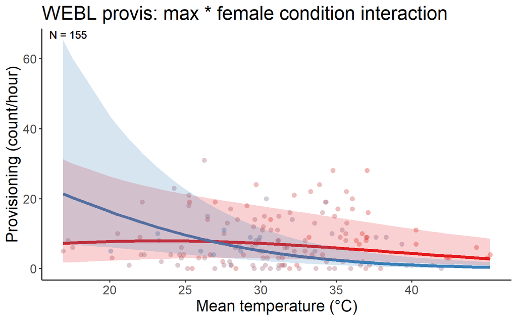

```r
(figq2h1_webl <- predict_response(m_webl_q2h1,terms = c("mean_temp_scaled [all]","female_condition_scaled [-2,2]"),margin = "marginalmeans") %>%
    plot(line_size = 1.5,alpha = .2,show_data = TRUE,limit_range = TRUE) +
    # aes(linetype = .data[["group"]]) +
    theme_classic() +
    # facet_wrap(~ group, ncol = 2) +
    xlab("Mean temperature (\u00b0C)") +
    ylab("Provisioning (count/hour)") +
    # scale_fill_viridis(discrete = TRUE) +
    # scale_color_viridis(discrete = TRUE) +
    theme(text = element_text(size = 16)) +
    labs(title =  "WEBL provis: max * female condition interaction") +
    scale_x_continuous(trans = temp_trans_webl_q2h1,
                       breaks = c((20-mean_temp_webl_q2h1)/sd_temp_webl_q2h1,
                                  (25-mean_temp_webl_q2h1)/sd_temp_webl_q2h1,
                                  (30-mean_temp_webl_q2h1)/sd_temp_webl_q2h1,
                                  (35-mean_temp_webl_q2h1)/sd_temp_webl_q2h1,
                                  (40-mean_temp_webl_q2h1)/sd_temp_webl_q2h1),
                       # breaks = c(20,30,40,50),
                       # labels = c("20","30","40","50"),
                       # limits = c((15-mean(g$meanmaxtempI,na.rm = TRUE))/sd(g$meanmaxtempI,na.rm = TRUE),
                       #            (55-mean(g$meanmaxtempI,na.rm = TRUE))/sd(g$meanmaxtempI,na.rm = TRUE))
                       # limits = c(18,5)
    ) +
    # scale_linetype_manual(values = c("Forest" = "solid","Orchard" = "dashed","Grassland" = "solid","Row crop" = "dotted")) +
    #ylim(-5,5) +
    geom_text(data = dat_text_webl_q2h1, mapping = aes(x = -Inf, y = Inf,label = label),hjust = -.2, vjust = 1.2,inherit.aes = FALSE) +
    theme(legend.position = "none")
)
```

When it’s hot, females in better condition provision less. Maybe they have the capacity to compensate?

### TRES

```
G3;Data points may overlap. Use the `jitter` argument to add some amount of random variation to the
  location of data points and avoid overplotting.
gScale for y is already present.
```

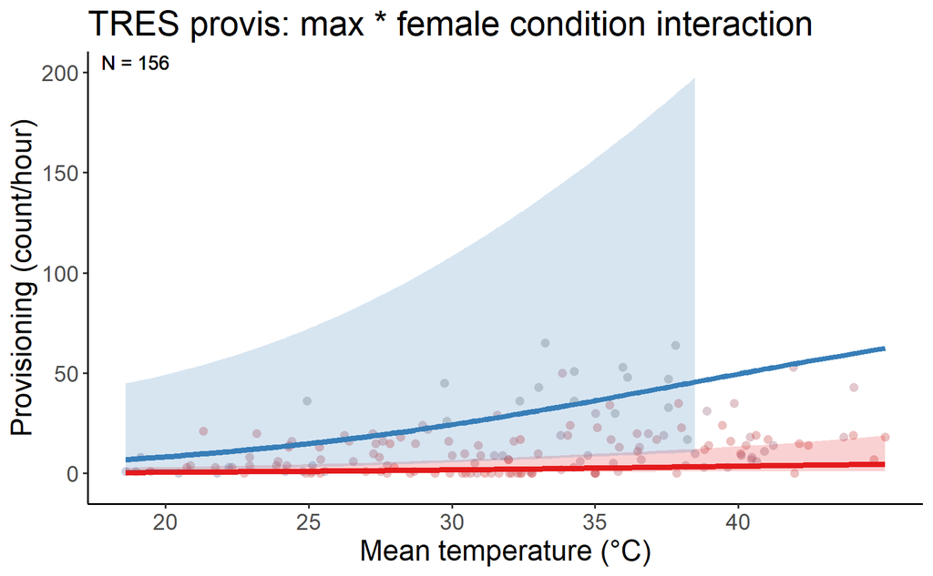

```r
(figq2h1_tres <- predict_response(m_tres_q2h1,terms = c("mean_temp_scaled [all]","female_condition_scaled [-2,2]"),margin = "marginalmeans") %>%
    plot(line_size = 1.5,alpha = .2,show_data = TRUE,limit_range = TRUE) +
    # aes(linetype = .data[["group"]]) +
    theme_classic() +
    # facet_wrap(~ group, ncol = 2) +
    xlab("Mean temperature (\u00b0C)") +
    ylab("Provisioning (count/hour)") +
    # scale_fill_viridis(discrete = TRUE) +
    # scale_color_viridis(discrete = TRUE) +
    theme(text = element_text(size = 16)) +
    labs(title =  "TRES provis: max * female condition interaction") +
    scale_x_continuous(trans = temp_trans_tres_q2h1,
                       breaks = c((20-mean_temp_tres_q2h1)/sd_temp_tres_q2h1,
                                  (25-mean_temp_tres_q2h1)/sd_temp_tres_q2h1,
                                  (30-mean_temp_tres_q2h1)/sd_temp_tres_q2h1,
                                  (35-mean_temp_tres_q2h1)/sd_temp_tres_q2h1,
                                  (40-mean_temp_tres_q2h1)/sd_temp_tres_q2h1),
                       # breaks = c(20,30,40,50),
                       # labels = c("20","30","40","50"),
                       # limits = c((15-mean(g$meanmaxtempI,na.rm = TRUE))/sd(g$meanmaxtempI,na.rm = TRUE),
                       #            (55-mean(g$meanmaxtempI,na.rm = TRUE))/sd(g$meanmaxtempI,na.rm = TRUE))
                       # limits = c(18,5)
    ) +
    # scale_linetype_manual(values = c("Forest" = "solid","Orchard" = "dashed","Grassland" = "solid","Row crop" = "dotted")) +
    ylim(-5,200) +
    geom_text(data = dat_text_tres_q2h1, mapping = aes(x = -Inf, y = Inf,label = label),hjust = -.2, vjust = 1.2,inherit.aes = FALSE) +
    theme(legend.position = "none")
)
```

So for TRES, when females are in better body condition, there’s more provisioning, and when it’s hot, there’s also more provisioning. But no interaction between the two.

## Q2H2

2. How does female body condition mediates provisioning We hypothesized that females in better condition (mass/tarsus) would be
1. (H1) less likely than females in worse condition to reduce their visits during hot periods because they are able to mobilize the energy required to engage in more energetically costly active thermoregulatory behaviors and
2. (H2) more likely than females in worse condition to maintain total provisioning visits by increasing visit rates during cooler hours of the day.

### WEBL

```r
summary(m_WEBL)
```

```
Linear mixed model fit by REML. t-tests use Satterthwaite's method ['lmerModLmerTest']
Formula: sqrt(mean_visits_h) ~ max_temp_h_scaled * female_condition_scaled +
    mean_nestling_age_scaled + brood_size_scaled + year_fct +      (1 | site:attempt_id)
   Data: dplyr::filter(p_sum, !is.na(diff_visits), !is.na(female_condition),
    !is.na(diff_temp), !is.na(mean_nestling_age), !is.na(brood_size),
    !is.na(year_fct), !is.na(site), !is.na(attempt_id), species ==
        "WEBL") %>% mutate(across(c(max_temp_h, female_condition,
    mean_nestling_age, brood_size), ~scale(.x)[, 1], .names = "{.col}_scaled"))

REML criterion at convergence: 28.9

Scaled residuals:
     Min       1Q   Median       3Q      Max
-0.62635 -0.35020 -0.11309  0.02926  1.39825

Random effects:
 Groups          Name        Variance Std.Dev.
 site:attempt_id (Intercept) 0.4719   0.6870
 Residual                    0.7205   0.8488
Number of obs: 12, groups:  site:attempt_id, 9

Fixed effects:
                                          Estimate Std. Error      df t value Pr(>|t|)
(Intercept)                                 2.6747     0.5362  2.1074   4.988   0.0341 *
max_temp_h_scaled                          -0.1701     0.4236  1.5331  -0.402   0.7368
female_condition_scaled                    -0.7244     0.3935  3.8678  -1.841   0.1419
mean_nestling_age_scaled                    0.6877     0.3647  2.7948   1.885   0.1626
brood_size_scaled                           0.5416     0.4535  4.7939   1.194   0.2881
year_fct2023                               -1.0526     0.7898  3.1871  -1.333   0.2699
max_temp_h_scaled:female_condition_scaled   0.1438     0.3944  2.8742   0.365   0.7405
---
Signif. codes:  0 ‘***’ 0.001 ‘**’ 0.01 ‘*’ 0.05 ‘.’ 0.1 ‘ ’ 1

Correlation of Fixed Effects:
            (Intr) mx_t__ fml_c_ mn_n__ brd_s_ y_2023
mx_tmp_h_sc  0.121
fml_cndtn_s -0.144  0.054
mn_nstlng__  0.024 -0.469 -0.117
brd_sz_scld -0.234 -0.339 -0.262 -0.039
yer_fct2023 -0.756 -0.144  0.258 -0.004  0.265
mx_tmp__:__ -0.339 -0.486 -0.285  0.045  0.648  0.301
```

Doesn’t seem like condition interacts with temp to alter time-based compensation for WEBL

### TRES

```r
summary(m_TRES)
```

```
Linear mixed model fit by REML. t-tests use Satterthwaite's method ['lmerModLmerTest']
Formula: sqrt(mean_visits_h) ~ max_temp_h_scaled * female_condition_scaled +
    mean_nestling_age_scaled + brood_size_scaled + year_fct +      (1 | site:attempt_id)
   Data: dplyr::filter(p_sum, !is.na(diff_visits), !is.na(female_condition),
    !is.na(diff_temp), !is.na(mean_nestling_age), !is.na(brood_size),
    !is.na(year_fct), !is.na(site), !is.na(attempt_id), species ==
        "TRES") %>% mutate(across(c(max_temp_h, female_condition,
    mean_nestling_age, brood_size), ~scale(.x)[, 1], .names = "{.col}_scaled"))

REML criterion at convergence: 44.8

Scaled residuals:
     Min       1Q   Median       3Q      Max
-0.80789 -0.39684 -0.02452  0.37332  0.63338

Random effects:
 Groups          Name        Variance Std.Dev.
 site:attempt_id (Intercept) 3.7126   1.9268
 Residual                    0.7667   0.8756
Number of obs: 15, groups:  site:attempt_id, 11

Fixed effects:
                                           Estimate Std. Error        df t value Pr(>|t|)
(Intercept)                                3.117632   1.112705  6.911430   2.802   0.0268 *
max_temp_h_scaled                          1.549582   0.535403  1.114374   2.894   0.1907
female_condition_scaled                    1.426693   0.940665  7.147223   1.517   0.1723
mean_nestling_age_scaled                  -0.009051   0.422289  1.538632  -0.021   0.9853
brood_size_scaled                          1.571789   1.035031  5.650320   1.519   0.1827
year_fct2023                              -1.520498   1.916513  6.530379  -0.793   0.4554
max_temp_h_scaled:female_condition_scaled  2.119553   1.168627  7.328314   1.814   0.1107
---
Signif. codes:  0 ‘***’ 0.001 ‘**’ 0.01 ‘*’ 0.05 ‘.’ 0.1 ‘ ’ 1

Correlation of Fixed Effects:
            (Intr) mx_t__ fml_c_ mn_n__ brd_s_ y_2023
mx_tmp_h_sc -0.340
fml_cndtn_s  0.542 -0.384
mn_nstlng__  0.174 -0.440  0.267
brd_sz_scld  0.387 -0.010  0.505  0.098
yer_fct2023 -0.720  0.267 -0.577 -0.033 -0.653
mx_tmp__:__ -0.220  0.313  0.022 -0.357  0.281 -0.214
```

I think the TRES data is getting thin on the ground for this question

## Q3H1

3. How does heat affect baseline and stress-induced? Elaborate Hp for baseline and stress-induced
1. H1: females that experienced heat over the prior day will be more likely to show elevated baseline corticosterone levels because they may upregulate their HPA axis in response to more challenging heat conditions
2. H2: females that experienced heat over the prior week will be more likely to show elevated stress-induced corticosterone levels because challenging environmental conditions are correlated with elevated stress-induced corticosterone levels.